# Bayesian Modeling of Choice

Felix Jan Nitsch

8/29/2019

# Rough Agenda

1. Today: What and Why
2. Model Structure Specification
3. Prior Specification
4. Implementation in JAGS
5. Fitting Model in R
6. Some results
7. Outlook and discussion

# Why Bayesian Parameter Estimation (and not MLE)

- We can express and specify uncertainty
- We have to make prior assumptions explicit
- We can use hierarchical models

# Objective: Understanding the Principle

- Topic: Bayesian Computational Modeling of Choice
- I will use R and JAGS (arbitrary choice)
  - Other alternatives: Stan, PyMC3
- I will talk about choices under risk, specifically prospect theory
  - While it is a common application and model, it is just an example
  - Other interesting models: Multinomial Process Models, Diffusion Models etc.

# Sources

[figure not shown]

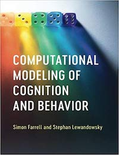

- Doing Bayesian Data Analysis, John K. Kruschke
- Computational Modeling of Cognition and Behavior, Farrell & Lewandowsky
- Nilsson, H., Rieskamp, J., & Wagenmakers, E.-J. (2011). Hierarchical Bayesian parameter estimation for cumulative prospect theory. Journal of Mathematical Psychology, 55, 84-93.
  - Presentation is mostly based on their paper and publicly available code

# Cumulative Prospect Theory

- Enhancement of Subjective Expected Utility Theory (SEU)
- Can account for a series of deviations from SEU
  - Reflection Effect
  - Inconsistent risk aversion/risk seeking
- Both values and probabilities are transformed domain-dependently
- The general form of the $SV$ (similar to SEU) of a prospect $O$ is given by:

$$SV(O) = \pi(p_i)u(x_i)$$
$$O: x_i \leftarrow p_i$$

# Component 1: Domain-dependent Utility Function

The utility function is domain dependent:

$$u(x)=
\begin{cases}
x^\alpha \leftarrow x\geq0 \\
-\lambda(-x)^\beta \leftarrow x < 0
\end{cases}$$
with

$$0\leq\alpha,\beta\leq1 \\
\lambda > 0$$

# Component 2: Probability Weights

Probability weights are also domain dependent

$$\pi(p_i) = \frac{p_i^{c(x_i)}}{(p_i^{c(x_i)}+[1-p_i]^{c(x_i)})^{1/c(x_i)}}$$
with

$$c(x)=
\begin{cases}
\gamma \leftarrow x\geq0 \\
\delta \leftarrow x < 0
\end{cases}$$
and

$$0\leq\gamma,\delta\leq1$$

- as long as $c<1$, small probabilities are overestimated and large probablities are underestimated

# Visualisation of Utility Function and Probability Weights

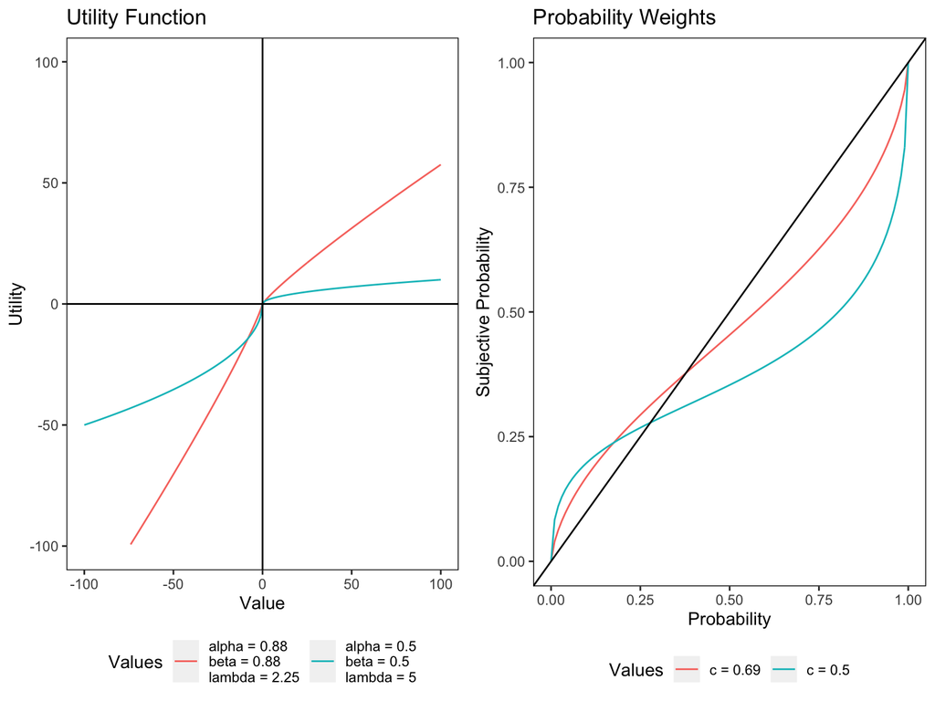

# Component 3: Luce Choice Rule

- Original CPT is deterministic, highest SEU option is always chosen
- Problem: Behaviour is noisy
- We need an error model to account for behaviour
- Simplest solution: Some form of simple scalability
  - Choice probability is a monotone function of SEU difference
- Example: logistic Luce choice rule

$$Pr(O_A,O_B) = \frac{1}
{1 + e^{\phi [SV(O_B)-SV(O_A)]}}$$
with

$$\phi \geq 0$$

- $\phi$ is a sensitivity parameter
- For $\phi=0$, choice behaviour is uniform random ($Pr(O_A,O_B)=0.5$)
- As $\phi$ grows larger, choice becomes more sensitve for SEU differences

# Visualisation of logistic Luce Choice Rule

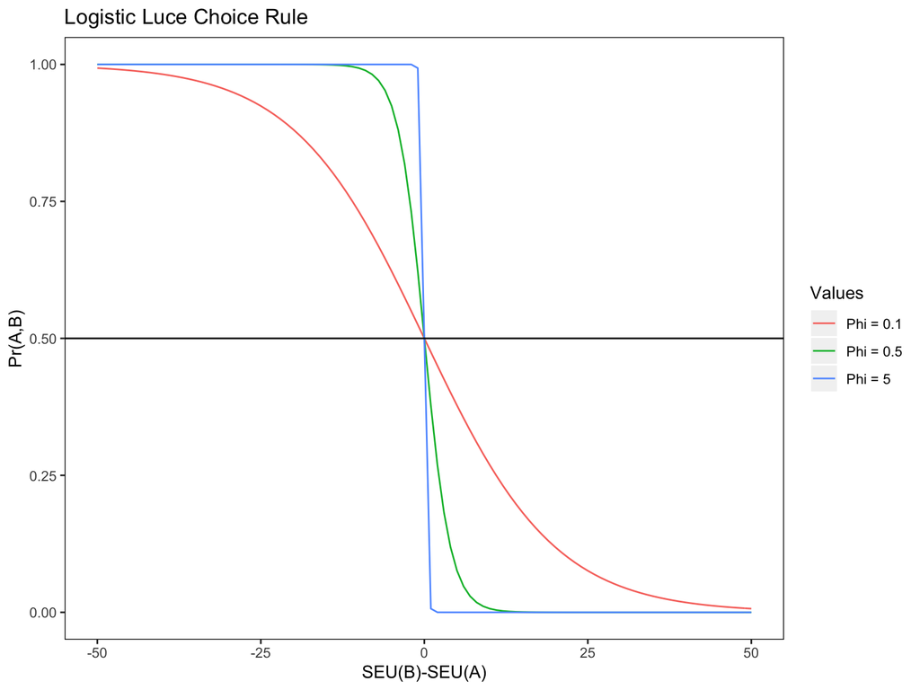

# Component 4: Bernoulli Trials

Finally we model the decision between two prospects as a Bernoulli trial

$R_{O_A, O_B} \stackrel{}{\sim} dbern(Pr(O_A, O_B))$

- dbern is the Bernoulli probability density function

# Priors as an expression about our beliefs of the probability distribution of the model parameters

- We model subjects with individual parameters
- But: Subjects are similar
  - Parameters are drawn from joint distribution
- We assume that parameters are stable
  - Implies no learning
  - Implies stable preferences

# Transformation of parameters for estimation

Given are the following constraints for all probabilistic CPT parameters:

$$\alpha, \beta, \gamma, \delta \in[0,1]\\
\lambda, \phi \in[0, \infty]$$

To faciliate hierarchical modeling, we probit transform $\alpha, \beta$, $\gamma$ and $\delta$

Transformed parameters cover the entire real line

$$\alpha^\phi \in [\infty_-,\infty_+] = \Theta^{-1}(\alpha)\\
\beta^\phi \in [\infty_-,\infty_+] = \Theta^{-1}(\beta)\\
\gamma^\phi \in [\infty_-,\infty_+] = \Theta^{-1}(\gamma)\\
\delta^\phi \in [\infty_-,\infty_+] = \Theta^{-1}(\delta)$$
Further, we log transform $\lambda$ and $\phi$

$$\lambda^{log} \in [0,\infty_+] = log(\lambda) \\
\phi^{log} \in [0,\infty_+] = log(\phi)$$

# Specification of Subject Level Priors

We assume the transformed parameters to be drawn from independent group-level normal distributions:

$$\alpha^\phi_i \stackrel{}{\sim} dnorm(\mu_\alpha, \sigma_\alpha)\\
\beta^\phi_i \stackrel{}{\sim} dnorm(\mu_\beta, \sigma_\beta)\\
\gamma^\phi_i \stackrel{}{\sim} dnorm(\mu_\gamma, \sigma_\gamma)\\
\delta^\phi_i \stackrel{}{\sim} dnorm(\mu_\delta, \sigma_\delta)\\$$
We assume the rest of the parameters to be drawn from independent group-level log-normal distributions:

$$\lambda^{log}_i \stackrel{}{\sim} dlnorm(\mu_\lambda, \sigma_\lambda)\\
\phi^{log}_i \stackrel{}{\sim} dlnorm(\mu_\phi, \sigma_\phi)$$

# Specification of Group Level Priors

Mostly uninformative priors
$$\mu_\alpha, \mu_\beta, \mu_\gamma, \mu_\delta \stackrel{}{\sim} dnorm(0,1)\\
\sigma_\alpha, \sigma_\beta, \sigma_\gamma, \sigma_\delta \stackrel{}{\sim} dunif(0, 10)\\$$

Priors for $\lambda$ and $\phi$ restrict eligible parameter values to a range of $[0.1, 5]$, based on authors’experience

$$\mu_\lambda, \mu_\phi \stackrel{}{\sim} dunif(-2.30, 1.61)\\
\sigma_\lambda, \sigma_\phi \stackrel{}{\sim} dunif(0, 1.13)$$

# Imports

```r
library(runjags)
library(rjags)
library(mcmcplots)
library(HDInterval)
```

# Model Specification in JAGS

```
# Fits Cumulative Prospect Theory
# Data from Rieskamp (30 paritipants, 60 gamble-pairs
# with positive outcomes, 60 gamble-pairs with negative
# outcomes, and 60 gamble-pairs with mixed outcomes)


model
{


  # The model assumes that every participant has a unique parameter-value
  # on each of the six parameters of hierarchical-CPT
  # (see, Nilsson, Rieskamp, & Wagnemakers, 2010).
  # Furthermore, it assumes that the individual values on parameter-dimension X
  # are sampled from the hyperdistribution for X. This has to be defined in the model code.


  for (j in 1:30) {

    # We start by defining that participant j has a unique parameter-value
    # on each of the six parameters: alpha, beta, gamma, delta, lambda, and luce
    # (the choice-rule parameter).

    alpha[j] <- phi(alpha_phi[j])
    beta[j] <- phi(beta_phi[j])
    gamma[j] <- phi(gamma_phi[j])
    delta[j] <- phi(delta_phi[j])
    luce[j]   <- exp(lluce[j])
    lambda[j] <- exp(llambda[j])

    # We put group-level normal distributions on the individual parameters:

    alpha_phi[j] ~ dnorm(mu_phi_alpha,tau_phi_alpha) T(-3, 3)
    beta_phi[j] ~ dnorm(mu_phi_beta,tau_phi_beta) T(-3, 3)
    gamma_phi[j] ~ dnorm(mu_phi_gamma,tau_phi_gamma) T(-3, 3)
    delta_phi[j] ~ dnorm(mu_phi_delta,tau_phi_delta) T(-3, 3)
    lluce[j] ~ dnorm(lmu_luce, ltau_luce)
    llambda[j] ~ dnorm(lmu_lambda, ltau_lambda)
  }

```

[output cut: 126 more lines]

```

      w_x_b[i,j] <- pow(prospects_b[i,2],gamma[j]) / pow(z_b[i,j],(1/gamma[j]))
      w_y_b[i,j] <- pow(prospects_b[i,4],delta[j]) / pow(z_b[i,j],(1/delta[j]))
      z_b[i,j]   <- pow(prospects_b[i,2],gamma[j]) + pow(prospects_b[i,4],delta[j])

      Vf_b[i,j]  <- w_x_b[i,j] * v_x_b[i,j] + w_y_b[i,j] * v_y_b[i,j]
    }

    # Item-Loop, mixed gambles,choice-rule
    for (i in 121:180) {
      binval[i,j] <- (1)/(1+exp((-1*luce[j])*(Vf_b[i,j]-Vf_a[i,j])))
      rawdata[i,j] ~ dbern(binval[i,j])
    }
  }
}
```

# Fit Model to Data

```r
# Load information about the 180 gamble-pairs used in Rieskamp (2008). GambleA.txt and GambleB.txt are
# structured as follows: value of outcome 1 (column 1), probability of outcome 1 (column 2), value of outcome 2 # (column 3), probability of outcome 2 (column 4) (gambles in rows).
prospects_b <- as.matrix(read.table("NilssonEtAl2011_code/GambleB.txt"))
prospects_a <- as.matrix(read.table("NilssonEtAl2011_code/GambleA.txt"))

# Load data (choice made by the first participant when presented the second gamble-pair is saved in
# column 1 row 2)
rawdata <- as.matrix(read.table("NilssonEtAl2011_code/Rieskamp_data.txt"))

# Define what information that should be passed on to WinBugs
data  = list("prospects_a" = prospects_a,
             "prospects_b" = prospects_b,
             "rawdata" = rawdata)

# Define initial values for variables (variables are defined in: cpt_hierarchical_model.txt)
inits = function()
{

  list(mu_phi_alpha = 0.7, sigma_phi_alpha = 1, mu_phi_beta = 0.7,
       sigma_phi_beta = 1,
       mu_phi_gamma = 0.7, sigma_phi_gamma = 1, mu_phi_delta = 0.7,
       sigma_phi_delta = 1,
       lmu_lambda = 0, lsigma_lambda = 0.5, lmu_luce = 0)

}

# Define the variables of interest.
monitored_parameters = c("alpha", "mu_phi_alpha", "mu_alpha", "sigma_phi_alpha",
               "beta", "mu_phi_beta", "mu_beta", "sigma_phi_beta",
               "gamma", "mu_phi_gamma", "mu_gamma", "sigma_phi_gamma",
               "delta", "mu_phi_delta", "mu_delta", "sigma_phi_delta",
               "lambda", "lmu_lambda", "mu_lambda", "lsigma_lambda",
               "luce", "lmu_luce", "mu_luce", "lsigma_luce")

# Run MCMC
mcmcfin <- run.jags(model = "CPT_model.j",
                    data = data,
                    inits = inits,
                    n.chains = 2,
                    sample = 10000,
                    adapt = 1000,
                    burnin = 1000,
                    thin = 10,
                    monitor = monitored_parameters,
                    method = "parallel"
                    )

# Store posterior means for later
posterior_means <- as.matrix(apply(as.matrix(as.mcmc.list(mcmcfin)), 2, mean))
write.csv(posterior_means, "posterior_means.csv")
```

# Convergence diagnostics

- Before we rush to drawing conclusions from our model we first must inspect convergence
- There is no way to *confirm* convergence, so better be paranoid
- Convergence is influenced by MCMC sample size, parameter specifications and model structure

```r
mcmcfin <- results.jags("runjagsfiles")
```

```
## Simulation complete.  Reading coda files...
## Coda files loaded successfully
## Note: Summary statistics were not produced as there are >50
## monitored variables
## [To override this behaviour see ?add.summary and ?runjags.options]
## FALSEFinished running the simulation
```

```r
gelman.diag(mcmcfin)
```

```
## Potential scale reduction factors:
##
##                 Point est. Upper C.I.
## alpha[1]                 1       1.00
## alpha[2]                 1       1.00
## alpha[3]                 1       1.00
## alpha[4]                 1       1.00
## alpha[5]                 1       1.00
## alpha[6]                 1       1.00
## alpha[7]                 1       1.00
## alpha[8]                 1       1.00
## alpha[9]                 1       1.00
## alpha[10]                1       1.00
## alpha[11]                1       1.00
## alpha[12]                1       1.00
## alpha[13]                1       1.00
## alpha[14]                1       1.00
## alpha[15]                1       1.00
## alpha[16]                1       1.00
## alpha[17]                1       1.00
## alpha[18]                1       1.00
## alpha[19]                1       1.00
## alpha[20]                1       1.00
## alpha[21]                1       1.00
## alpha[22]                1       1.00
## alpha[23]                1       1.00
## alpha[24]                1       1.00
## alpha[25]                1       1.00
## alpha[26]                1       1.00
## alpha[27]                1       1.00
## alpha[28]                1       1.00
## alpha[29]                1       1.00
## alpha[30]                1       1.00
## mu_phi_alpha             1       1.00
## mu_alpha                 1       1.00
## sigma_phi_alpha          1       1.01
## beta[1]                  1       1.00
## beta[2]                  1       1.00
## beta[3]                  1       1.00
## beta[4]                  1       1.00
```

[output cut: 150 more lines]

```
## luce[23]                 1       1.00
## luce[24]                 1       1.00
## luce[25]                 1       1.00
## luce[26]                 1       1.00
## luce[27]                 1       1.00
## luce[28]                 1       1.00
## luce[29]                 1       1.01
## luce[30]                 1       1.00
## lmu_luce                 1       1.00
## mu_luce                  1       1.00
## lsigma_luce              1       1.00
##
## Multivariate psrf
##
## 1.02
```

```r
mcmcplot(mcmcfin)
```

# Results

Mini-Summary of the posterior distribution

```r
mcmcfin_reduced <- results.jags("runjagsfiles",
                                read.monitor = c("mu_alpha", "mu_beta", "mu_gamma",
                                                 "mu_delta", "mu_lambda", "mu_phi"))
```

```
## Simulation complete.  Reading coda files...
## Coda files loaded successfully
## Calculating summary statistics...
## Calculating the Gelman-Rubin statistic for 5 variables....
## Finished running the simulation
```

```r
hdi(mcmcfin_reduced)
```

```
##       mu_alpha  mu_beta mu_gamma mu_delta mu_lambda
## lower 0.783703 0.911262 0.616173 0.606708  0.598148
## upper 0.933398 0.999998 0.804920 0.999853  0.888687
## attr(,"credMass")
## [1] 0.95
```

# Typical subject

Plugging the posterior means of the mean of the group level parameter distributions into our model:

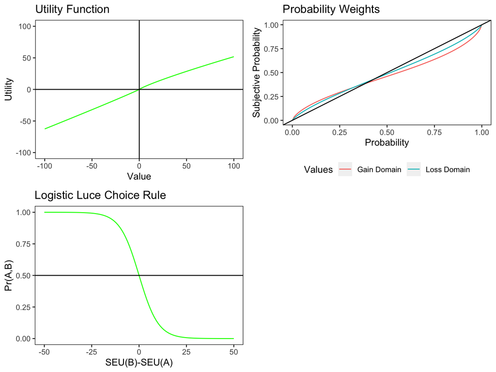

# Outlook

- Posterior Predictive Checks
- Using Bayesian Models for out of sample prediction
- (Hierarchical) Model Comparison